# The Architecture of Intelligence

## Connectionists: Bolivarian Contribution

- Two inspiring contributors from the Bolivarian nations!

[figure not shown]

## Evolutionaries — Selection Algorithm

- Roots: Darwin, formalized by Holland (1975)
- Evolve a population — mutation, crossover, selection
- No gradient, no labels — only a fitness score
- Optimization: genetic algorithms / evolutionary search
- Niche but creative: architecture search, robot morphology
- EXAMPLE: Avoiding immune response for gene envelope

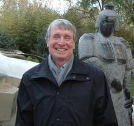

John H. Holland

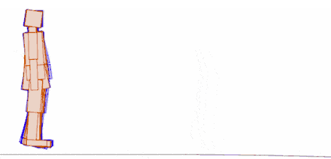

An evolved gait — most of the population falls over

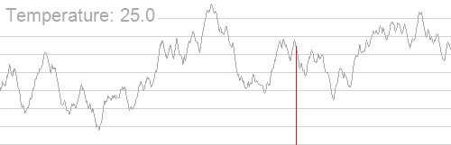

Simulated annealing — escaping local optima

## Bayesians — Belief as Probability

- Roots: Bayes (1763), Laplace
- Learning = updating a distribution over hypotheses
- Prior + likelihood → posterior
- Optimization: probabilistic inference (MCMC, variational inference)
- Calibrated uncertainty, at a computational cost
- EXAMPLE: Soldier Death Benefit Pensions

$$\underset{\color{#f0a868}{\text{posterior}}}{\color{#f0a868}{P(H \mid D)}} \;=\; \frac{\underset{\color{#63b3a6}{\text{likelihood}}}{\color{#63b3a6}{P(D \mid H)}}\;\cdot\;\underset{\color{#7aa0e0}{\text{prior}}}{\color{#7aa0e0}{P(H)}}}{\underset{\color{#9aa0aa}{\text{evidence}}}{\color{#9aa0aa}{P(D)}}}$$

$$\underset{\color{#e06c75}{\text{predictive}}}{\color{#e06c75}{P(x^{*} \mid D)}} \;=\; \int \color{#63b3a6}{P(x^{*} \mid H)}\; \color{#f0a868}{P(H \mid D)}\; dH \qquad \text{— average over every hypothesis, don't pick one}$$

## Analogizers — Similarity

- Roots: psychology — reasoning from prior cases
- k-nearest neighbors, SVMs, the kernel trick
- Optimization: constrained optimization to maximize margin (SVMs)
- Legacy: recommendation, few-shot via embeddings
- EXAMPLE: Locating outperforming stock pairs

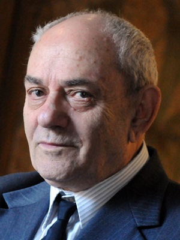

[figure not shown]

Vladimir Vapnik — co-inventor of the SVM

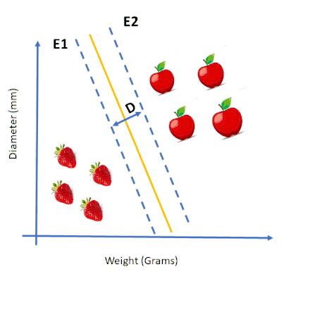

The margin, widened until it cannot be

## The Frontier Borrows From All Five

- No production system is one tribe
- LLMs: connectionist core, Bayesian uncertainty, symbolic tools, RL tuning
- Domingos’ provocation: one master algorithm?
- Which synthesis will *your* work advance?

## VI. State of the Art

## Brittle AI & the Reasoning Gap

- Narrow, brittle outside the training distribution
- The frontier problem is sample-efficient reasoning, not scale
- Performance can mask absent understanding
- ARC-AGI-3 **saturated** in a year — at thousands of dollars in compute
- The compute-capped ARC Prize is still unclaimed

[figure not shown]

[figure not shown]

## System 1 vs. System 2

- After Kahneman: fast intuition vs. slow reasoning
- LLMs excel at System 1, stumble at System 2
- “Reasoning” models narrow the gap at inference time
- Open and fast-moving

[figure not shown]

## Reality Gets a Vote

- Knowledge is what survives a test
- Code and maths moved fastest — they can be **checked**
- Fluency with no verifier → hallucination
- Essays, strategy, taste, most real tasks: no oracle

[figure not shown]

## Pearl’s Ladder

- **See** — P(y | x)
- **Do** — P(y | do(x))
- **Imagine** — what if I had?
- LLMs just see, no doing or imagining without a verifier!
- Can’t watch your way to cause

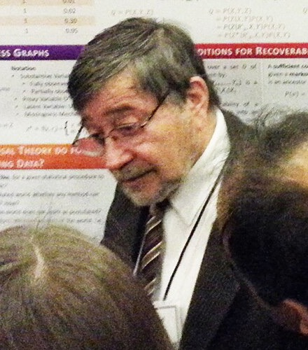

## The Experiment Is the Intervention

- **do(x)** — reach in, *set* x by hand, cutting its usual causes
- That severed graph is what an experiment *is* — randomise, don’t just watch
- **Verifying and causing are one move**
- To do experiments and find cause, you need a body

[figure not shown]

## VII. What We Want from AGI

## Generality, Efficiency, Reasoning

- **Generality** — competence transfers to the untrained
- **Sample Efficiency** — human-like, from few examples
- **Robust Reasoning** — multi-step, causal, self-correcting

## Memory, Grounding, Aligned Autonomy

- **Persistent Memory** — no catastrophic forgetting
- **Grounded World Models** — causal, ideally embodied
- **Autonomy + Alignment** — open-ended yet controllable
- The last is a constraint — and the highest-stakes one

## VIII. The Future

## Embodied AI & Moravec’s Paradox

- Intelligence may require a body
- Moravec: reasoning is cheap, sensorimotor skill is dear
- Crossing a room is harder than grandmaster chess

## Foundation Models Meet Robotics

- Model “brains” in capable “bodies”
- Surgery, deep-sea exploration, autonomous logistics
- The loop closes: sense → predict → act → learn
- Where the next decade concentrates

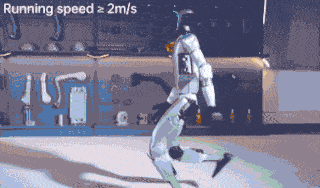

Unitree G1 — a body waiting for a better brain

## AI Ethics — Beyond My Expertise

- **Cheap Dopamine** — engineered attention capture
- **Economic Effects** — labour, wealth concentration
- **Children** — growing up AI-saturated
- **Distribution** — who reaps the fruits of the technology
- A prior, held lightly: fewer regulations tend to serve better

## Key Takeaways

- “AI” is an ambiguous term — today it means LLMs
- Minds run on prediction — octopus to cortex to transformer
- Human intelligence is the ML task list, written first in our biology
- The open gaps — reasoning, memory, grounding, alignment — are the agenda

## Closing Remarks

*This PhD program is not about mastering today’s tools — it is about building the future.*

You are the architects of the world models that will define the coming decade. The questions left open tonight — what consciousness is, how memory should persist, what closes the reasoning gap, what we should and should not want from AGI — are not gaps in this lecture.

**They are your thesis directions.**

## Key References I

*Foundations & cognition*

- Turing, A. (1950). Computing Machinery and Intelligence. *Mind*.
- Russell, S. & Norvig, P. (2020). *Artificial Intelligence: A Modern Approach* (4th ed.)
- Kahneman, D. (2011). *Thinking, Fast and Slow*.
- Friston, K. (2010). The free-energy principle: a unified brain theory? *Nature Reviews Neuroscience*.

## Key References II

*Symbolic & neural roots*

- Newell, A. & Simon, H. (1976). Computer science as empirical inquiry: symbols and search. *CACM*.
- McCulloch, W. & Pitts, W. (1943). A logical calculus of ideas immanent in nervous activity.
- Rosenblatt, F. (1958). The perceptron. *Psychological Review*.
- Minsky, M. & Papert, S. (1969). *Perceptrons*.

## Key References III

*Learning at scale*

- Rumelhart, D., Hinton, G. & Williams, R. (1986). Learning representations by back-propagating errors. *Nature*.
- Vaswani, A. et al. (2017). Attention Is All You Need. *NeurIPS*.
- Hinton, G., Bengio, Y. & LeCun, Y. — 2018 ACM A.M. Turing Award, for deep neural networks
- Dean, J. et al. (2012). Large scale distributed deep networks. *NeurIPS*.

## Key References IV

*Defining intelligence*

- Holland, J. (1975). *Adaptation in Natural and Artificial Systems*.
- Sutton, R. (2019). *The Bitter Lesson*.
- Chollet, F. (2019). On the measure of intelligence. *arXiv:1911.01547*.
- Domingos, P. (2015). *The Master Algorithm*.
- Moravec, H. (1988). *Mind Children*.

## Image Credits

- Bonobo — natataek, CC BY-SA 3.0
- Octopus — Diego Delso, CC BY-SA 4.0
- L. Messi goal clip (Getafe, 2007) — broadcast footage, rights holder unidentified
- Mirror self-recognition (bear, infant, child animations) — via Medium
- G. Hinton — Cmichel67, CC BY-SA 4.0
- Y. LeCun — J. Barande, CC BY-SA 2.0
- Y. Bengio — Xuthoria, CC BY-SA 4.0
- J. Schmidhuber — ITU/R. Farrell, CC BY 2.0
- D. Kahneman — nrkbeta, CC BY-SA 2.0
- J. Pearl — Better Than Bacon, CC BY 2.0
- J. McCarthy — null0, CC BY-SA 2.0
- M. Minsky — OLPC, CC BY 3.0
- C. Shannon — Tekniska museet, CC BY 2.0
- F. Chollet — Ramosset, CC BY-SA 4.0
- A. Turing — Elliott & Fry, public domain
- T. Bayes — public domain (attribution disputed)
- Soviet flag — public domain
- Early human migrations map — Dbachmann, CC BY-SA 4.0
- Acheulean handaxe (Saint-Acheul) — Didier Descouens, CC BY-SA 4.0
- Simulated annealing — Kingpin13, CC0
- Map boundaries — Natural Earth, public domain
- J. Holland, V. Vapnik, J. Tenenbaum, K. Friston — no free licence identified; used under fair dealing for education
- Portrait with sculpture — personal photograph, used with permission
- Attention animation — BertViz, via comet.com
- Diffusion denoising animation — via Towards Data Science
- Decision tree animation — via Medium
- *Inside Out* emotions clip — © Disney/Pixar, via Medium; used under fair dealing for education
- Biological neuron animation — via Telefónica Tech
- Evolved walker animation — via kottke.org
- SVM margin animation — via Medium
- ANI/AGI/ASI illustration — via Medium
- AI history timeline — via LinkedIn
- Unitree G1 robot animation — via roboticgizmos.com
- Coffee-making robot animation — via Mothership
- ARC-AGI task animation & ARC-AGI-3 leaderboard — © ARC Prize Foundation, via arcprize.org
- M. Tyson quote poster — rights holder unidentified; used under fair dealing for education

Photographs from Wikimedia Commons unless noted. Titled slide image: Piedras del Tunjo.

## Discussion

*What is the most important open problem in AI — and how will you spend the next five years on it?*